# Practice Machine Learning - Assignment

JJ

23/8/2020

# Reading the data and packages

```r
training <- read.csv("pml-training.csv", na.strings = c("NA",""))
testing <- read.csv("pml-testing.csv", na.strings = c("NA",""))

library(caret)
library(randomForest)
```

```r
library(plotly)
library(dplyr)
```

# Choosing variables

```r
str(training)
```

```
## 'data.frame':    19622 obs. of  160 variables:
##  $ X                       : int  1 2 3 4 5 6 7 8 9 10 ...
##  $ user_name               : chr  "carlitos" "carlitos" "carlitos" "carlitos" ...
##  $ raw_timestamp_part_1    : int  1323084231 1323084231 1323084231 1323084232 1323084232 1323084232 1323084232 1323084232 1323084232 1323084232 ...
##  $ raw_timestamp_part_2    : int  788290 808298 820366 120339 196328 304277 368296 440390 484323 484434 ...
##  $ cvtd_timestamp          : chr  "05/12/2011 11:23" "05/12/2011 11:23" "05/12/2011 11:23" "05/12/2011 11:23" ...
##  $ new_window              : chr  "no" "no" "no" "no" ...
##  $ num_window              : int  11 11 11 12 12 12 12 12 12 12 ...
##  $ roll_belt               : num  1.41 1.41 1.42 1.48 1.48 1.45 1.42 1.42 1.43 1.45 ...
##  $ pitch_belt              : num  8.07 8.07 8.07 8.05 8.07 8.06 8.09 8.13 8.16 8.17 ...
##  $ yaw_belt                : num  -94.4 -94.4 -94.4 -94.4 -94.4 -94.4 -94.4 -94.4 -94.4 -94.4 ...
##  $ total_accel_belt        : int  3 3 3 3 3 3 3 3 3 3 ...
##  $ kurtosis_roll_belt      : chr  NA NA NA NA ...
##  $ kurtosis_picth_belt     : chr  NA NA NA NA ...
##  $ kurtosis_yaw_belt       : chr  NA NA NA NA ...
```

[output cut: 86 more lines]

The structure of the data shows that there are several variables with a lot of missing values, therefore these will be taken out of the analysis in order to build a model.

```r
# Training dataset
training <- training %>% select(num_window:total_accel_belt, gyros_belt_x:total_accel_arm, gyros_arm_x:magnet_arm_z, roll_dumbbell:yaw_dumbbell, total_accel_dumbbell, gyros_dumbbell_x:yaw_forearm, total_accel_forearm, gyros_forearm_x:classe)
```

In this case, the training and testing dataset should have the same variables, so I select these variables for the testing data as well.

```r
# Testing dataset
testing <- testing %>% select(num_window:total_accel_belt, gyros_belt_x:total_accel_arm, gyros_arm_x:magnet_arm_z, roll_dumbbell:yaw_dumbbell, total_accel_dumbbell, gyros_dumbbell_x:yaw_forearm, total_accel_forearm, gyros_forearm_x:magnet_forearm_z)
```

```r
str(training)
```

```
## 'data.frame':    19622 obs. of  54 variables:
##  $ num_window          : int  11 11 11 12 12 12 12 12 12 12 ...
##  $ roll_belt           : num  1.41 1.41 1.42 1.48 1.48 1.45 1.42 1.42 1.43 1.45 ...
##  $ pitch_belt          : num  8.07 8.07 8.07 8.05 8.07 8.06 8.09 8.13 8.16 8.17 ...
##  $ yaw_belt            : num  -94.4 -94.4 -94.4 -94.4 -94.4 -94.4 -94.4 -94.4 -94.4 -94.4 ...
##  $ total_accel_belt    : int  3 3 3 3 3 3 3 3 3 3 ...
##  $ gyros_belt_x        : num  0 0.02 0 0.02 0.02 0.02 0.02 0.02 0.02 0.03 ...
##  $ gyros_belt_y        : num  0 0 0 0 0.02 0 0 0 0 0 ...
##  $ gyros_belt_z        : num  -0.02 -0.02 -0.02 -0.03 -0.02 -0.02 -0.02 -0.02 -0.02 0 ...
##  $ accel_belt_x        : int  -21 -22 -20 -22 -21 -21 -22 -22 -20 -21 ...
##  $ accel_belt_y        : int  4 4 5 3 2 4 3 4 2 4 ...
##  $ accel_belt_z        : int  22 22 23 21 24 21 21 21 24 22 ...
##  $ magnet_belt_x       : int  -3 -7 -2 -6 -6 0 -4 -2 1 -3 ...
##  $ magnet_belt_y       : int  599 608 600 604 600 603 599 603 602 609 ...
##  $ magnet_belt_z       : int  -313 -311 -305 -310 -302 -312 -311 -313 -312 -308 ...
```

[output cut: 40 more lines]

```r
training$classe <- factor(training$classe)
```

# Choosing a method

I will be using Random Forests since generally this is a good method for predictions. Also, cross validation is necessary in order to evaluate how well this method works. In this case, I use the k-fold method, and since the dataset has almost 20000 observations, a value for k=10 is acceptable.

```r
set.seed(1240)
folds <- createFolds(1:nrow(training), k = 10)
```

# Cross validation

A for loop can be made to store the level of accuracy that each of the folds has, in order to average these 10 different values to see how good the model is (and the variables) to determine the class.

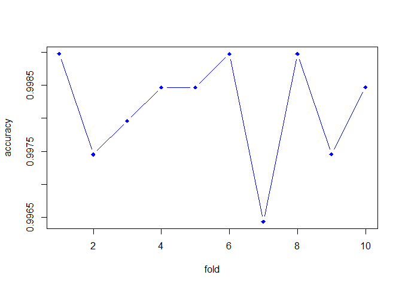

```r
# Cross Validation

ACC<-c()
# Loop to calculate the accuracy of the model
for (i in 1:10) {
    test.fold <- training[folds[[i]],]
    train.fold <- training[-folds[[i]],]
    mod <- randomForest(classe ~ ., method="class", data = train.fold)
    pred <- predict(mod, test.fold)
    t <- confusionMatrix(pred, test.fold$classe)
    ACC[i] <- t$overall[1] # Storing the accuracy for each fold
}
plot(ACC, type = "b", col = "blue", pch = 18, xlab = "fold", ylab = "accuracy")
```

```r
# Mean accuracy of the 10 folds
mean(ACC)
```

```
## [1] 0.9981652
```

The plot shows that all of these values are close to 0.99 for each iteration, which means that the model has a pretty good accuracy. Also, the mean is 0.998, very close to 1.

# Predicting the new data (20 observations)

```r
mod.rf <- randomForest(classe ~ ., method="class", data = training)
pred2 <- predict(mod.rf, testing)
```

Finally, the prediction for the 20 observations can be made through the model, although in this case, the model has to use the whole training dataset instead of just a fold.

```r
# classification for the 20 observations
pred2
```

```
##  1  2  3  4  5  6  7  8  9 10 11 12 13 14 15 16 17 18 19 20
##  B  A  B  A  A  E  D  B  A  A  B  C  B  A  E  E  A  B  B  B
## Levels: A B C D E
```